# DEPLr: A Simulation Depletion Model for Octopus

Abdelouahed BEN MHAMED

2015-04-15

# Introduction

DEPLr in an implementation of a Monte Carlo simulation depletion model applied to octopus. This package allow the user to project the population of a stock, or different stocks of octopus with no interaction, in the future and get a summary of the state of the population. It also provides different outputs like:

1. The path of the abundance of the stock along the fishing season
2. The path of the biomass for each zone
3. The catch in number and weight along the weeks of the fishing season for each zone and fleet
4. And the cpue of each fleet in each zone

# Input file

There is an example of the input file in the package that could be uploaded using the *DEPLSim* method. This input file include all basic elements needed to run the simulation model. A full description of the input file could be found in *Appendix A*:

```r
library(DEPLr)
sim=DEPLSim(file = "/home/benmhamed/Wahid/my_packages/DEPLr/input/sim1.inp")
class(sim)
```

```
## [1] "DEPLSim"
## attr(,"package")
## [1] "DEPLr"
```

To have an overveiw of the DEPLSim object *sim* we write:

```r
str(sim)
```

```
## Formal class 'DEPLSim' [package "DEPLr"] with 8 slots
##   ..@ controle:Formal class 'DEPLPar' [package "DEPLr"] with 3 slots
##   .. .. ..@ value: num [1:10] 0.00 1.37e-02 1.00e-01 1.00e-01 1.00e+02 1.90e+01 3.00 3.00 5.00 5.00e+06
##   .. .. ..@ name : chr [1:10] "cstNM" "valNM" "proErr" "obsErr" ...
##   .. .. ..@ unit : chr ""
##   ..@ params  :Formal class 'DEPLPar' [package "DEPLr"] with 3 slots
##   .. .. ..@ value: num [1:4] 1.19 2.95 6.81e-03 8.36e+02
##   .. .. ..@ name : chr [1:2] "L-W" "G-F"
##   .. .. ..@ unit : chr ""
##   ..@ zones   :Formal class 'DEPLZone' [package "DEPLr"] with 7 slots
##   .. .. ..@ n         : num 3
##   .. .. ..@ name      : chr [1:3] "A-Côte" "A-Large" "B"
##   .. .. ..@ fleet     :Formal class 'DEPLFleet' [package "DEPLr"] with 3 slots
##   .. .. .. .. ..@ n           : num 3
##   .. .. .. .. ..@ name        : chr [1:3] "Artisanal" "Côtier" "Hauturier"
##   .. .. .. .. ..@ catchability: num [1:3] 3.0e-05 3.4e-05 9.0e-05
##   .. .. ..@ initAbund : num [1:3] 10070000 26920000 26700000
##   .. .. ..@ initLength: num [1:3] 7.12 7.07 6.78
##   .. .. ..@ propRec   : num [1:3] 0.3 0.3 0.4
##   .. .. ..@ data      : num [1:19, 1:5, 1:3] 7763 6186 5466 5495 5768 ...
##   ..@ catch.n : logi [1(1d)] NA
##   ..@ catch.wt: logi [1(1d)] NA
##   ..@ stock.n : logi [1(1d)] NA
##   ..@ stock.wt: logi [1(1d)] NA
##   ..@ cpue    : logi [1(1d)] NA
```

As you can see, there are eight main feilds in the DEPLSim object which we are going to present briefly:

1. *controle*: This slot is a *DEPLPar* object which contains some parameters of the simulation model. To look further on it type *controle(sim)*. We used *knitr::kable* just for formating the table to look like this:

```r
knitr::kable(controle(sim))
```

| Parameter | Description | Value | Unit |
| --- | --- | --- | --- |
| cstNM | Constant natural mortality(1=TRUE,0=FALSE) | 0.00e+00 |  |
| valNM | Value of natural mortality per week | 1.37e-02 |  |
| proErr | Process error | 1.00e-01 |  |
| obsErr | Observation error | 1.00e-01 |  |
| nbrSim | Number of simulations | 1.00e+02 |  |
| season | Length of fishing season in weeks | 1.90e+01 |  |
| nbrFleet | Number of fleets | 3.00e+00 |  |
| nbrZone | Number of Zones | 3.00e+00 |  |
| discard | Difference between survey and begining of fishing season | 5.00e+00 |  |
| recTot | Total recruitment | 5.00e+06 |  |

2. *params*: this slot is a *DEPLPar* object which contains the parameters of the *Length-Weight* relationship and the parameters of the *Growth* function of the octopus.
3. *zones*: this slot is a *DEPLZone* object. To have access to it we can use the following *script*:

```r
zone <- zones(sim)
# Get the names of zones
names(zone)
```

```
## [1] "A-Côte"  "A-Large" "B"
```

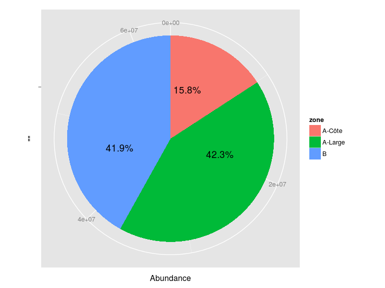

```r
# plot the proportion of initial abundance in each zone
plot(zone)
```

To get the fleets exploiting the zones we type:

```r
# Get the fleets exploiting the zones
fleet <- fleet(zone)
# To obtain names of each fleet
names(fleet)
```

```
## [1] "Artisanal" "Côtier"    "Hauturier"
```

```r
# To obtain the catchability of each fleet
catchability(fleet)
```

```
## [1] 3.0e-05 3.4e-05 9.0e-05
```

```r
# To display the Fleets with their catchabilities in a data.frame
as.data.frame(fleet)
```

```
##       Fleet Catchability
## 1 Artisanal      3.0e-05
## 2    Côtier      3.4e-05
## 3 Hauturier      9.0e-05
```

The last five fields of the DEPLSim object *sim* are _catch.n__, *catch.wt*, *stock.n*, *stock.wt* and *cpue*. These could be accessed with:

```r
catch.n(sim)
```

```
## [1] NA
```

```r
catch.wt(sim)
```

```
## [1] NA
```

```r
stock.n(sim)
```

```
## [1] NA
```

```r
stock.wt(sim)
```

```
## [1] NA
```

```r
index(sim)
```

```
## [1] NA
```

As you can see, these objects are empty, so to have them full, we have to run the simulation model using *run* method:

```r
# sim <- run(sim)
```

After runing the model you can se that the empty feilds are now having values. To ge summaries of the stock abundance, biomass, the catch in numbers and weight, and the cpue we use the following *script*:

```r
# Computing a summary of the catch in numbers
catchN <- summary(object = sim,"catch.n")
catchWT <- summary(object = sim,"catch.wt")
stockN <- summary(object = sim,"stock.n")
stockWT <- summary(object = sim,"stock.wt")
cpue <- summary(object = sim,"cpue")
head(catchN)
```

```
##   week     fleet   zone      mean    median       sd
## 1   W1 Artisanal A-Côte 2336016.2 2298723.3 244390.0
## 2   W2 Artisanal A-Côte 1463996.6 1442211.7 221848.7
## 3   W3 Artisanal A-Côte 1044525.5 1044522.0 170122.0
## 4   W4 Artisanal A-Côte  812000.4  823664.4 150439.2
## 5   W5 Artisanal A-Côte  726166.2  699586.4 164270.2
## 6   W6 Artisanal A-Côte  545334.6  527025.2 134624.8
```

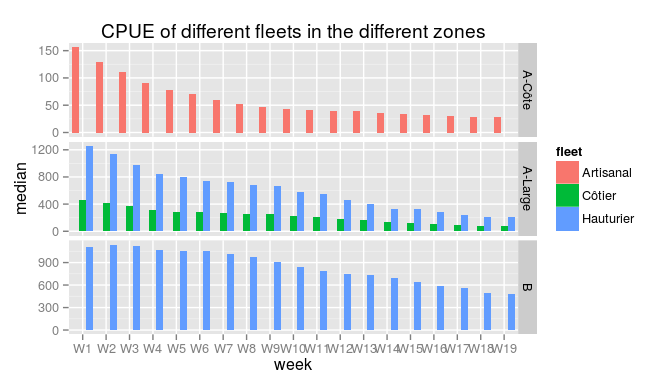

```r
library(ggplot2)
ggplot(cpue, aes(week, median, fill = fleet)) +
   geom_bar(position = "dodge",stat="identity") +
  facet_grid(facets = zone~.,scales="free_y") +
  ggtitle("CPUE of different fleets in the different zones")
```

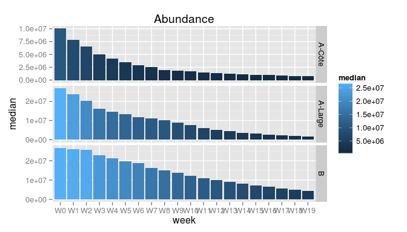

```r
ggplot(stockN, aes(week, median)) +
   geom_bar(aes(fill=median),stat="identity") +
  facet_grid(facets = zone~.,scales="free_y") +
  ggtitle("Abundance")
```

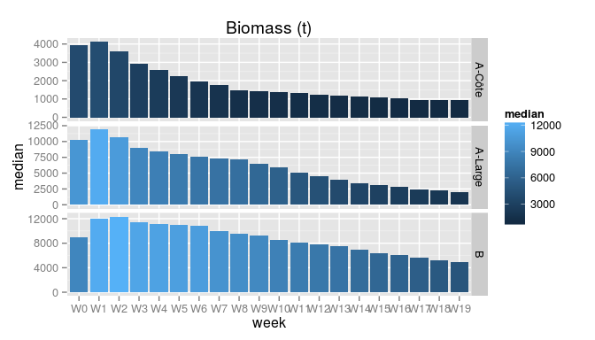

```r
ggplot(stockWT, aes(week, median)) +
   geom_bar(aes(fill=median),stat="identity") +
  facet_grid(facets = zone~.,scales="free_y") +
  ggtitle("Biomass (t)")
```

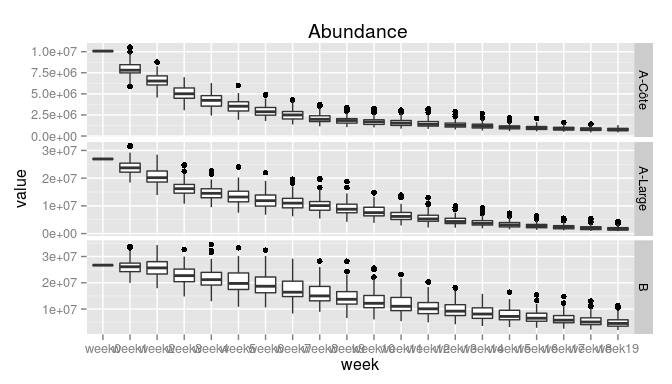

```r
library(plyr)
library(reshape2)
abundance <- stock.n(sim)
cpue <- index(sim)
dtN <- adply(.data = abundance,.margins = c(1,2,3),.fun = identity)
names(dtN) <- c("iter","week","zone","value")
ggplot(dtN, aes(week, value)) +
   geom_boxplot() +
  facet_grid(facets = zone~.,scales="free_y") +
  ggtitle("Abundance ")
```

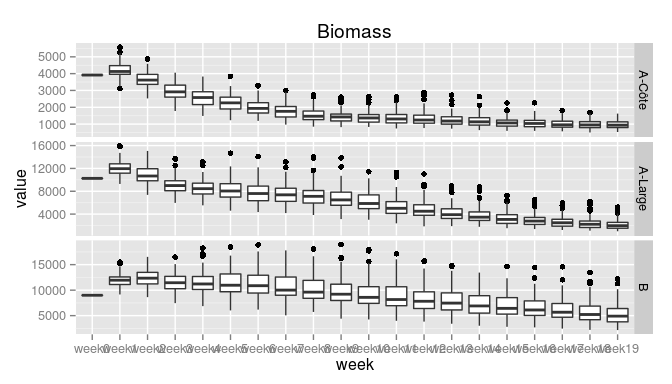

```r
biomass <- stock.wt(sim)
dtB <- adply(.data = biomass,.margins = c(1,2,3),.fun = identity)
names(dtB) <- c("iter","week","zone","value")
ggplot(dtB, aes(week, value)) +
   geom_boxplot() +
  facet_grid(facets = zone~.,scales="free_y") +
  ggtitle("Biomass")
```

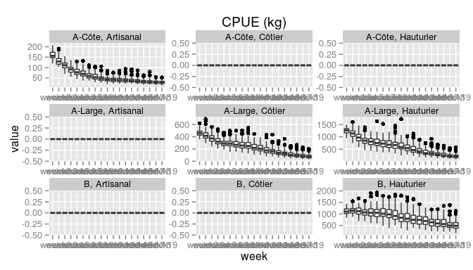

```r
cpue <- index(sim)
dtcpue <- adply(.data = cpue,.margins = c(1,2,3,4),.fun = identity)
names(dtcpue) <- c("iter","week","fleet","zone","value")
ggplot(dtcpue, aes(week, value)) +
   geom_boxplot() +
  facet_wrap(facets = zone~fleet,scales="free") +
  ggtitle("CPUE (kg)")
```

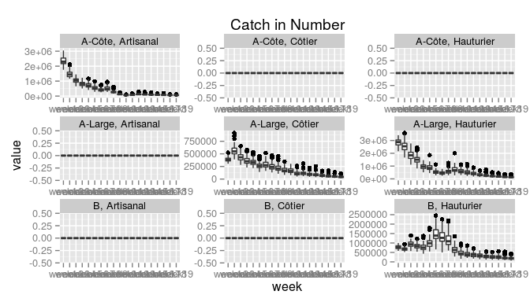

```r
catchn <- catch.n(sim)
dtcatchn <- adply(.data = catchn,.margins = c(1,2,3,4),.fun = identity)
names(dtcatchn) <- c("iter","week","fleet","zone","value")
ggplot(dtcatchn, aes(week, value)) +
   geom_boxplot() +
  facet_wrap(facets = zone~fleet,scales="free") +
  ggtitle("Catch in Number")
```

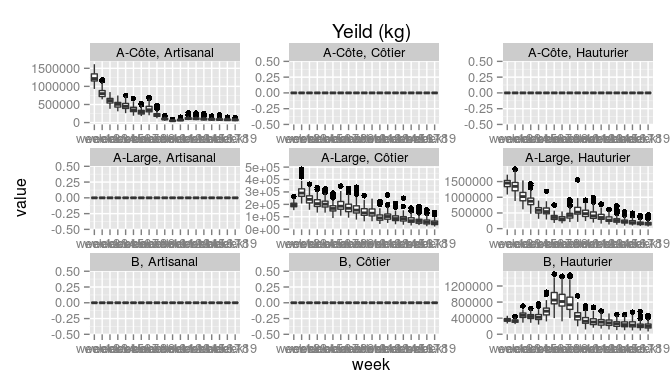

```r
catchwt <- catch.wt(sim)
dtcatchwt <- adply(.data = catchwt,.margins = c(1,2,3,4),.fun = identity)
names(dtcatchwt) <- c("iter","week","fleet","zone","value")
ggplot(dtcatchwt, aes(week, value)) +
   geom_boxplot() +
  facet_wrap(facets = zone~fleet,scales="free") +
  ggtitle("Yeild (kg)")
```